title: “Head Start for Data Scientist”

output:

html_document:

```
number_sections: TRUE

toc: TRUE

fig_height: 4

fig_width: 7

code_folding: show
```

## 0.1 Introduction.

On 14 April 1912, the [RMS Titanic](https://en.wikipedia.org/wiki/RMS_Titanic) struck a large iceberg and took approximately 1,500 of its passengers and crew below the icy depths of the Atlantic Ocean. Considered one of the worst peacetime disasters at sea, this tragic event led to the creation of numerous [safety regulations and policies](http://www.gc.noaa.gov/gcil_titanic-history.html) to prevent such a catastrophe from happening again. Some critics, however, argue that circumstances other than luck resulted in a disproportionate number of deaths. The purpose of this analysis is to explore factors that influenced a person’s likelihood to survive.

### 0.1.1 Software.

The following analysis was conducted in the [R software environment for statistical computing](https://www.r-project.org/).

Libraries:

```r
# data wrangling

library(tidyverse)

library(forcats)

library(stringr)

library(caTools)



# data assessment/visualizations

library(DT)

library(data.table)

library(pander)

library(ggplot2)

library(scales)

library(grid)

library(gridExtra)

library(corrplot)

library(VIM)

library(knitr)

library(vcd)

library(caret)





# model

library(xgboost)

library(MLmetrics)

library('randomForest')

library('rpart')

library('rpart.plot')

library('car')

library('e1071')

library(vcd)

library(ROCR)

library(pROC)

library(VIM)

library(glmnet)
```

```r
train <- read_csv('../input/train.csv')

test  <- read_csv('../input/test.csv')
```

```r
train$set <- "train"

test$set  <- "test"

test$Survived <- NA

full <- rbind(train, test)
```

lets do str, names, summary, glimpse,

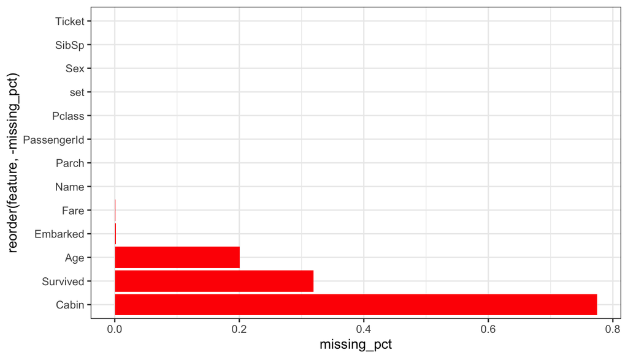

```r
# check data

str(full)



# dataset dimensions

dim(full)



# Unique values per column

lapply(full, function(x) length(unique(x)))



#Check for Missing values



missing_values <- full %>% summarize_all(funs(sum(is.na(.))/n()))



missing_values <- gather(missing_values, key="feature", value="missing_pct")

missing_values %>%

  ggplot(aes(x=reorder(feature,-missing_pct),y=missing_pct)) +

  geom_bar(stat="identity",fill="red")+

  coord_flip()+theme_bw()
```

```r
#Useful data quality function for missing values



checkColumn = function(df,colname){



  testData = df[[colname]]

  numMissing = max(sum(is.na(testData)|is.nan(testData)|testData==''),0)





  if (class(testData) == 'numeric' | class(testData) == 'Date' | class(testData) == 'difftime' | class(testData) == 'integer'){

    list('col' = colname,'class' = class(testData), 'num' = length(testData) - numMissing, 'numMissing' = numMissing, 'numInfinite' = sum(is.infinite(testData)), 'avgVal' = mean(testData,na.rm=TRUE), 'minVal' = round(min(testData,na.rm = TRUE)), 'maxVal' = round(max(testData,na.rm = TRUE)))

  } else{

    list('col' = colname,'class' = class(testData), 'num' = length(testData) - numMissing, 'numMissing' = numMissing, 'numInfinite' = NA,  'avgVal' = NA, 'minVal' = NA, 'maxVal' = NA)

  }



}

checkAllCols = function(df){

  resDF = data.frame()

  for (colName in names(df)){

    resDF = rbind(resDF,as.data.frame(checkColumn(df=df,colname=colName)))

  }

  resDF

}





datatable(checkAllCols(full), style="bootstrap", class="table-condensed", options = list(dom = 'tp',scrollX = TRUE))
```

[output not shown]

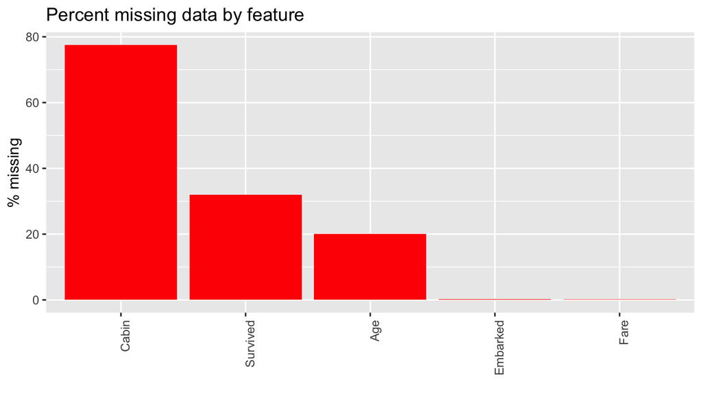

```r
miss_pct <- map_dbl(full, function(x) { round((sum(is.na(x)) / length(x)) * 100, 1) })



miss_pct <- miss_pct[miss_pct > 0]



data.frame(miss=miss_pct, var=names(miss_pct), row.names=NULL) %>%

    ggplot(aes(x=reorder(var, -miss), y=miss)) +

    geom_bar(stat='identity', fill='red') +

    labs(x='', y='% missing', title='Percent missing data by feature') +

    theme(axis.text.x=element_text(angle=90, hjust=1))
```

### 0.1.2 Age

Replace missing Age cells with the mean Age of all passengers on the Titanic.

```r
full <- full %>%

    mutate(

      Age = ifelse(is.na(Age), mean(full$Age, na.rm=TRUE), Age),

      `Age Group` = case_when(Age < 13 ~ "Age.0012",

                                 Age >= 13 & Age < 18 ~ "Age.1317",

                                 Age >= 18 & Age < 60 ~ "Age.1859",

                                 Age >= 60 ~ "Age.60Ov"))
```

### 0.1.3 Embarked

Use the most common code to replace NAs in the *Embarked* feature.

```r
full$Embarked <- replace(full$Embarked, which(is.na(full$Embarked)), 'S')
```

### 0.1.4 Titles

Extract an individual’s title from the *Name* feature.

```r
names <- full$Name

title <-  gsub("^.*, (.*?)\\..*$", "\\1", names)



full$title <- title



table(title)
```

```
## title
##         Capt          Col          Don         Dona           Dr
##            1            4            1            1            8
##     Jonkheer         Lady        Major       Master         Miss
##            1            1            2           61          260
##         Mlle          Mme           Mr          Mrs           Ms
##            2            1          757          197            2
##          Rev          Sir the Countess
##            8            1            1
```

```r
###MISS, Mrs, Master and Mr are taking more numbers



###Better to group Other titles into bigger basket by checking gender and survival rate to aviod any overfitting





full$title[full$title == 'Mlle']        <- 'Miss'

full$title[full$title == 'Ms']          <- 'Miss'

full$title[full$title == 'Mme']         <- 'Mrs'

full$title[full$title == 'Lady']          <- 'Miss'

full$title[full$title == 'Dona']          <- 'Miss'



## I am afraid creating a new varible with small data can causes a overfit

## However, My thinking is that combining below feauter into original variable may loss some predictive power as they are all army folks, doctor and nobel peoples



full$title[full$title == 'Capt']        <- 'Officer'

full$title[full$title == 'Col']        <- 'Officer'

full$title[full$title == 'Major']   <- 'Officer'

full$title[full$title == 'Dr']   <- 'Officer'

full$title[full$title == 'Rev']   <- 'Officer'

full$title[full$title == 'Don']   <- 'Officer'

full$title[full$title == 'Sir']   <- 'Officer'

full$title[full$title == 'the Countess']   <- 'Officer'

full$title[full$title == 'Jonkheer']   <- 'Officer'
```

### 0.1.5 Family Groups

Families are binned into a discretized feature based on family member count.

```r
full$FamilySize <-full$SibSp + full$Parch + 1

full$FamilySized[full$FamilySize == 1] <- 'Single'

full$FamilySized[full$FamilySize < 5 & full$FamilySize >= 2] <- 'Small'

full$FamilySized[full$FamilySize >= 5] <- 'Big'

full$FamilySized=as.factor(full$FamilySized)
```

###Tickets

Engineer features based on all the passengers with the same ticket.

```r
##Engineer features based on all the passengers with the same ticket

ticket.unique <- rep(0, nrow(full))

tickets <- unique(full$Ticket)



for (i in 1:length(tickets)) {

  current.ticket <- tickets[i]

  party.indexes <- which(full$Ticket == current.ticket)





  for (k in 1:length(party.indexes)) {

    ticket.unique[party.indexes[k]] <- length(party.indexes)

  }

}



full$ticket.unique <- ticket.unique





full$ticket.size[full$ticket.unique == 1]   <- 'Single'

full$ticket.size[full$ticket.unique < 5 & full$ticket.unique>= 2]   <- 'Small'

full$ticket.size[full$ticket.unique >= 5]   <- 'Big'
```

### 0.1.6 Independent Variable/Target

### 0.1.7 Survival

The independent variable, *Survived*, is labeled as a *Bernoulli trial* where a passenger or crew member surviving is encoded with the value of 1. Among observations in the train set, approximately 38% of passengers and crew survived.

```r
full <- full %>%

  mutate(Survived = case_when(Survived==1 ~ "Yes",

                              Survived==0 ~ "No"))



crude_summary <- full %>%

  filter(set=="train") %>%

  select(PassengerId, Survived) %>%

  group_by(Survived) %>%

  summarise(n = n()) %>%

  mutate(freq = n / sum(n))



crude_survrate <- crude_summary$freq[crude_summary$Survived=="Yes"]



kable(crude_summary, caption="2x2 Contingency Table on Survival.", format="markdown")
```

| Survived | n | freq |
| --- | --- | --- |
| No | 549 | 0.6161616 |
| Yes | 342 | 0.3838384 |

##Exploratory data analysis

In statistics, exploratory data analysis (EDA) is an approach to analyzing data sets to summarize their main characteristics, often with visual methods. A statistical model can be used or not, but primarily EDA is for seeing what the data can tell us beyond the formal modeling or hypothesis testing task.

For more ways of Data Visualization[refer data visualization handbook](https://www.kaggle.com/hiteshp/visualization-handbook)

### 0.1.8 Relationship Between Dependent and Independent Variables

### 0.1.9 Dependent Variables/Predictors

**Note - Go through each tab for different Variables**

### 0.1.10 Relationship to Survival Rate

#### Pclass

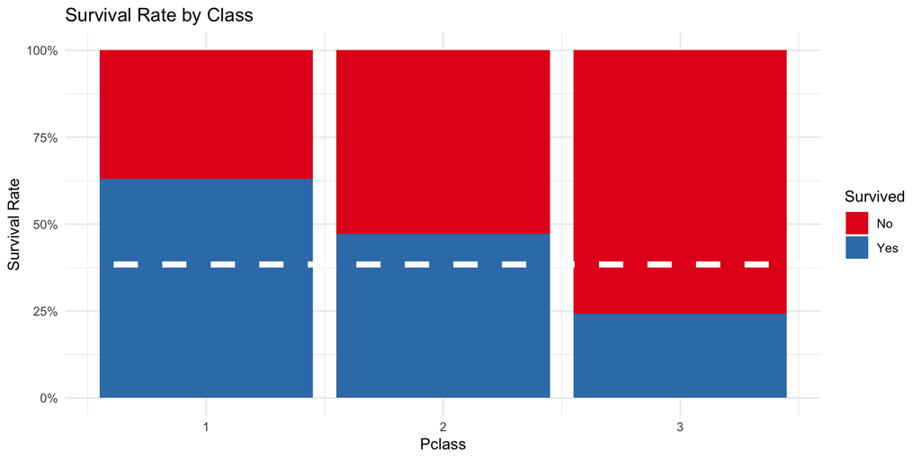

```r
ggplot(full %>% filter(set=="train"), aes(Pclass, fill=Survived)) +

  geom_bar(position = "fill") +

  scale_fill_brewer(palette="Set1") +

  scale_y_continuous(labels=percent) +

  ylab("Survival Rate") +

  geom_hline(yintercept=crude_survrate, col="white", lty=2, size=2) +

  ggtitle("Survival Rate by Class") +

  theme_minimal()
```

#### Sex

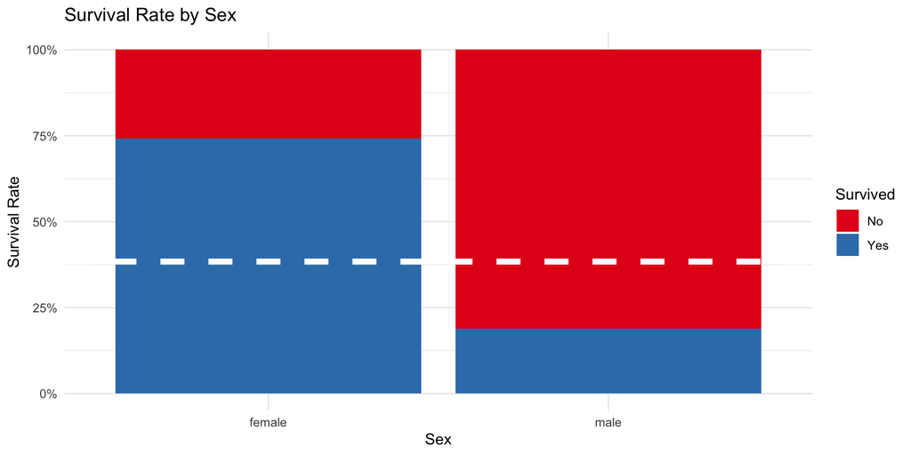

```r
ggplot(full %>% filter(set=="train"), aes(Sex, fill=Survived)) +

  geom_bar(position = "fill") +

  scale_fill_brewer(palette="Set1") +

  scale_y_continuous(labels=percent) +

  ylab("Survival Rate") +

  geom_hline(yintercept=crude_survrate, col="white", lty=2, size=2) +

  ggtitle("Survival Rate by Sex") +

  theme_minimal()
```

#### Age

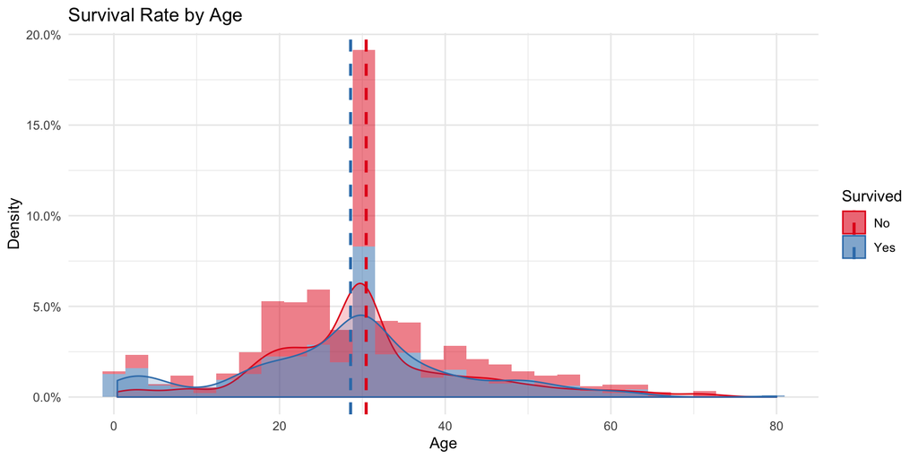

```r
tbl_age <- full %>%

  filter(set=="train") %>%

  select(Age, Survived) %>%

  group_by(Survived) %>%

  summarise(mean.age = mean(Age, na.rm=TRUE))



ggplot(full %>% filter(set=="train"), aes(Age, fill=Survived)) +

  geom_histogram(aes(y=..density..), alpha=0.5) +

  geom_density(alpha=.2, aes(colour=Survived)) +

  geom_vline(data=tbl_age, aes(xintercept=mean.age, colour=Survived), lty=2, size=1) +

  scale_fill_brewer(palette="Set1") +

  scale_colour_brewer(palette="Set1") +

  scale_y_continuous(labels=percent) +

  ylab("Density") +

  ggtitle("Survival Rate by Age") +

  theme_minimal()
```

#### Age Groups

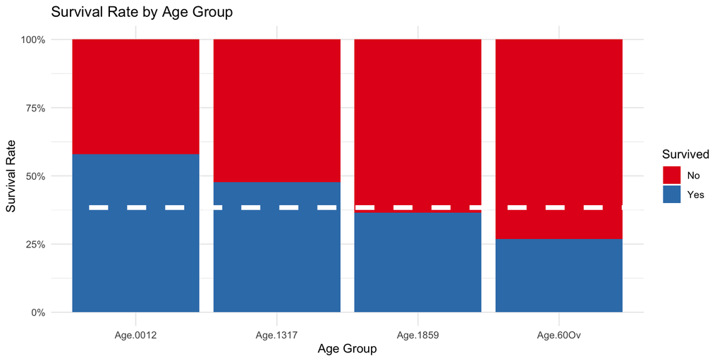

```r
ggplot(full %>% filter(set=="train" & !is.na(Age)), aes(`Age Group`, fill=Survived)) +

  geom_bar(position = "fill") +

  scale_fill_brewer(palette="Set1") +

  scale_y_continuous(labels=percent) +

  ylab("Survival Rate") +

  geom_hline(yintercept=crude_survrate, col="white", lty=2, size=2) +

  ggtitle("Survival Rate by Age Group") +

  theme_minimal()
```

#### SibSp

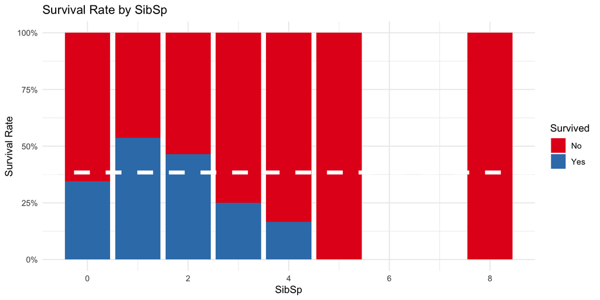

```r
ggplot(full %>% filter(set=="train"), aes(SibSp, fill=Survived)) +

  geom_bar(position = "fill") +

  scale_fill_brewer(palette="Set1") +

  scale_y_continuous(labels=percent) +

  ylab("Survival Rate") +

  geom_hline(yintercept=crude_survrate, col="white", lty=2, size=2) +

  ggtitle("Survival Rate by SibSp") +

  theme_minimal()
```

#### Parch

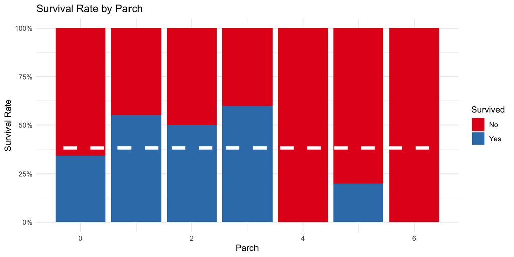

```r
ggplot(full %>% filter(set=="train"), aes(Parch, fill=Survived)) +

  geom_bar(position = "fill") +

  scale_fill_brewer(palette="Set1") +

  scale_y_continuous(labels=percent) +

  ylab("Survival Rate") +

  geom_hline(yintercept=crude_survrate, col="white", lty=2, size=2) +

  ggtitle("Survival Rate by Parch") +

  theme_minimal()
```

#### Embarked

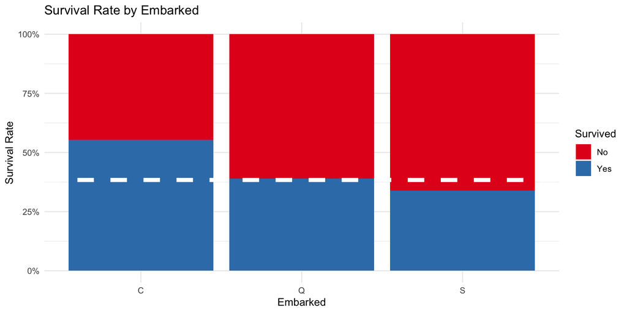

```r
ggplot(full %>% filter(set=="train"), aes(Embarked, fill=Survived)) +

  geom_bar(position = "fill") +

  scale_fill_brewer(palette="Set1") +

  scale_y_continuous(labels=percent) +

  ylab("Survival Rate") +

  geom_hline(yintercept=crude_survrate, col="white", lty=2, size=2) +

  ggtitle("Survival Rate by Embarked") +

  theme_minimal()
```

#### Title

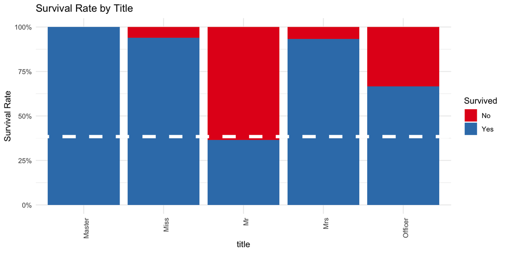

```r
ggplot(full %>% filter(set=="train") %>% na.omit, aes(title, fill=Survived)) +

  geom_bar(position="fill") +

  scale_fill_brewer(palette="Set1") +

  scale_y_continuous(labels=percent) +

  ylab("Survival Rate") +

  geom_hline(yintercept=crude_survrate, col="white", lty=2, size=2) +

  ggtitle("Survival Rate by Title") +

  theme_minimal() +

  theme(axis.text.x = element_text(angle = 90, hjust = 1))
```

#### Family

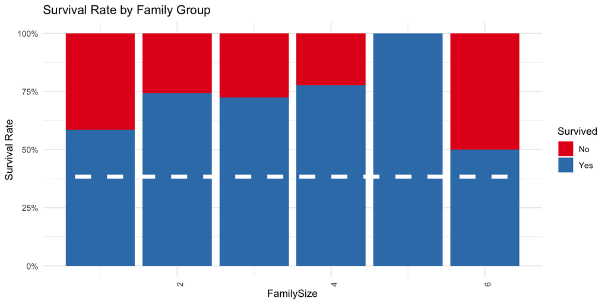

```r
ggplot(full %>% filter(set=="train") %>% na.omit, aes(`FamilySize`, fill=Survived)) +

  geom_bar(position="fill") +

  scale_fill_brewer(palette="Set1") +

  scale_y_continuous(labels=percent) +

  ylab("Survival Rate") +

  geom_hline(yintercept=crude_survrate, col="white", lty=2, size=2) +

  ggtitle("Survival Rate by Family Group") +

  theme_minimal() +

  theme(axis.text.x = element_text(angle = 90, hjust = 1))
```

**Note - Go through each tab for different Relationship to Frequency of Variables**

### 0.1.11 Relationship to Frequency

#### Pclass

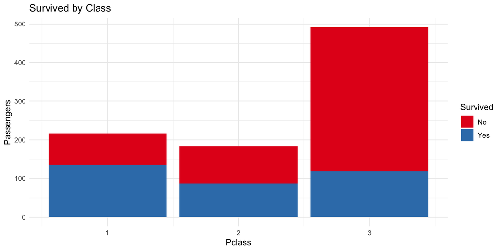

```r
ggplot(full %>% filter(set=="train"), aes(Pclass, fill=Survived)) +

  geom_bar(position="stack") +

  scale_fill_brewer(palette="Set1") +

  scale_y_continuous(labels=comma) +

  ylab("Passengers") +

  ggtitle("Survived by Class") +

  theme_minimal()
```

#### Sex

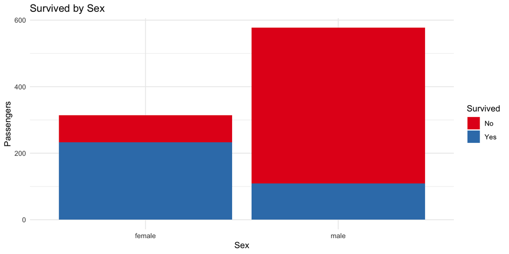

```r
ggplot(full %>% filter(set=="train"), aes(Sex, fill=Survived)) +

  geom_bar(position="stack") +

  scale_fill_brewer(palette="Set1") +

  scale_y_continuous(labels=percent) +

  scale_y_continuous(labels=comma) +

  ylab("Passengers") +

  ggtitle("Survived by Sex") +

  theme_minimal()
```

#### Age

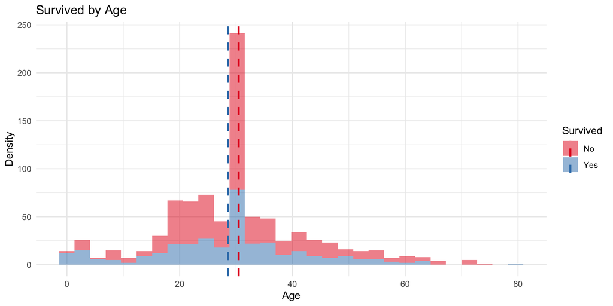

```r
ggplot(full %>% filter(set=="train"), aes(Age, fill=Survived)) +

  geom_histogram(aes(y=..count..), alpha=0.5) +

  geom_vline(data=tbl_age, aes(xintercept=mean.age, colour=Survived), lty=2, size=1) +

  scale_fill_brewer(palette="Set1") +

  scale_colour_brewer(palette="Set1") +

  scale_y_continuous(labels=comma) +

  ylab("Density") +

  ggtitle("Survived by Age") +

  theme_minimal()
```

#### Age Groups

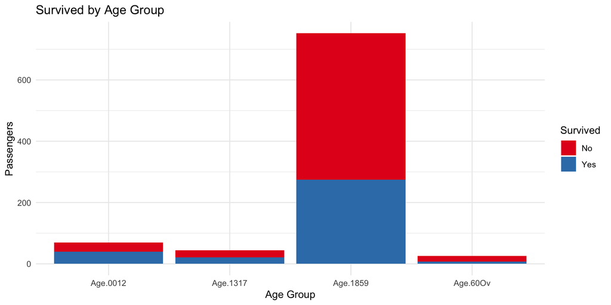

```r
ggplot(full %>% filter(set=="train" & !is.na(Age)), aes(`Age Group`, fill=Survived)) +

  geom_bar(position="stack") +

  scale_fill_brewer(palette="Set1") +

  scale_y_continuous(labels=comma) +

  ylab("Passengers") +

  ggtitle("Survived by Age Group") +

  theme_minimal()
```

#### SibSp

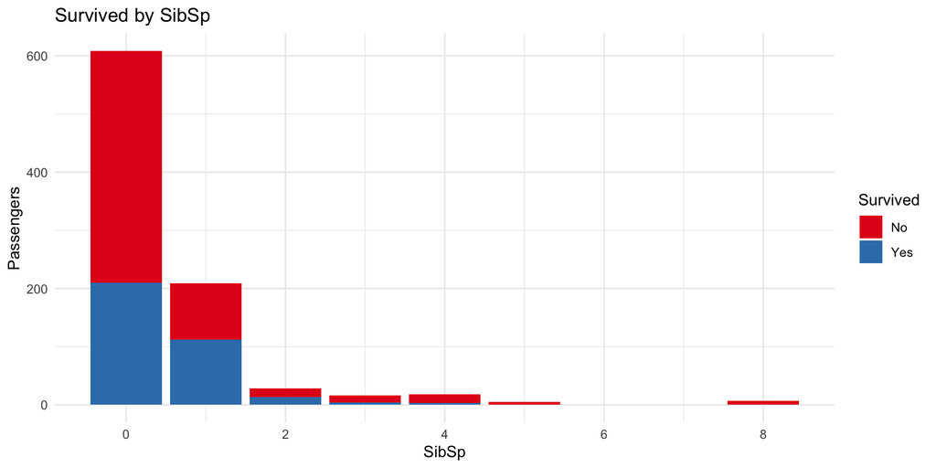

```r
ggplot(full %>% filter(set=="train"), aes(SibSp, fill=Survived)) +

  geom_bar(position="stack") +

  scale_fill_brewer(palette="Set1") +

  scale_y_continuous(labels=percent) +

  scale_y_continuous(labels=comma) +

  ylab("Passengers") +

  ggtitle("Survived by SibSp") +

  theme_minimal()
```

#### Parch

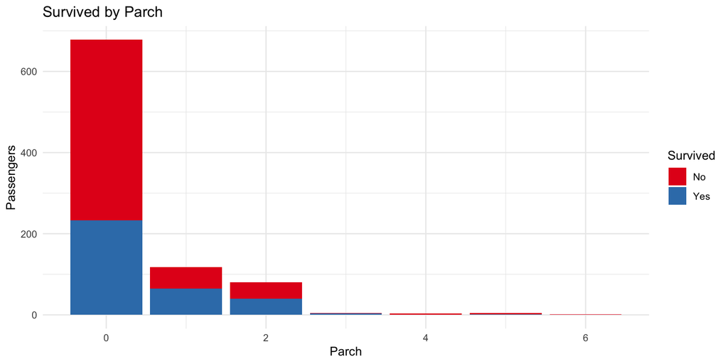

```r
ggplot(full %>% filter(set=="train"), aes(Parch, fill=Survived)) +

  geom_bar(position="stack") +

  scale_fill_brewer(palette="Set1") +

  scale_y_continuous(labels=comma) +

  ylab("Passengers") +

  ggtitle("Survived by Parch") +

  theme_minimal()
```

#### Embarked

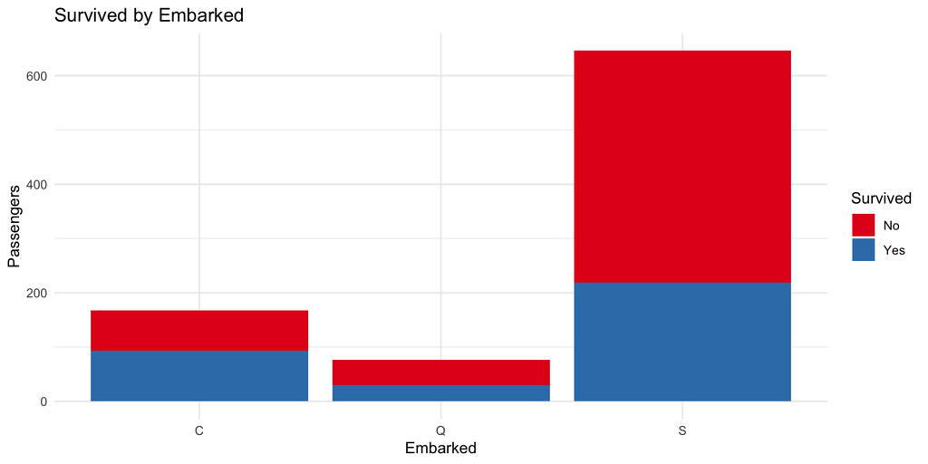

```r
ggplot(full %>% filter(set=="train"), aes(Embarked, fill=Survived)) +

  geom_bar(position="stack") +

  scale_fill_brewer(palette="Set1") +

  scale_y_continuous(labels=comma) +

  ylab("Passengers") +

  ggtitle("Survived by Embarked") +

  theme_minimal()
```

#### Title

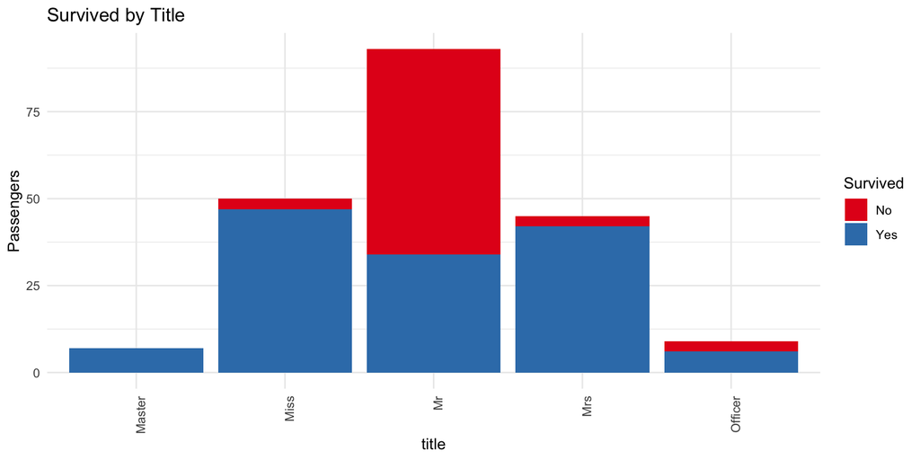

```r
ggplot(full %>% filter(set=="train") %>% na.omit, aes(title, fill=Survived)) +

  geom_bar(position="stack") +

  scale_fill_brewer(palette="Set1") +

  scale_y_continuous(labels=comma) +

  ylab("Passengers") +

  ggtitle("Survived by Title") +

  theme_minimal() +

  theme(axis.text.x = element_text(angle = 90, hjust = 1))
```

#### Family

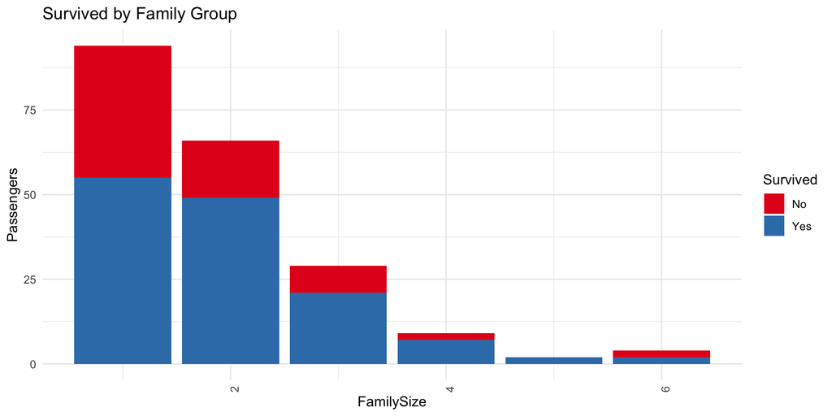

```r
ggplot(full %>% filter(set=="train") %>% na.omit, aes(`FamilySize`, fill=Survived)) +

  geom_bar(position="stack") +

  scale_fill_brewer(palette="Set1") +

  scale_y_continuous(labels=comma) +

  ylab("Passengers") +

  ggtitle("Survived by Family Group") +

  theme_minimal() +

  theme(axis.text.x = element_text(angle = 90, hjust = 1))
```

### 0.1.12 Interactive Relationships Between Variables

#### 0.1.12.1 Correlation Plot

Correlation measures between numeric features suggest redundant information such as *Fare* with *Pclass*. This relationship, however, may be distorted due to passengers who boarded as a family where *Fare* represents the sum of a family’s total cost.

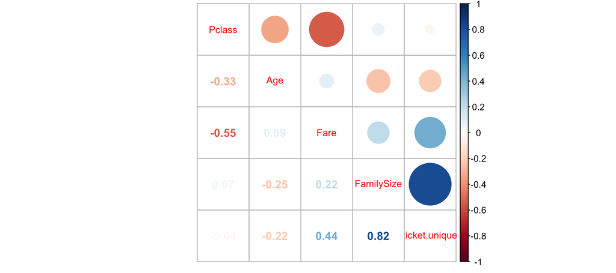

```r
tbl_corr <- full %>%

  filter(set=="train") %>%

  select(-PassengerId, -SibSp, -Parch) %>%

  select_if(is.numeric) %>%

  cor(use="complete.obs") %>%

  corrplot.mixed(tl.cex=0.85)
```

#### 0.1.12.2 Mosaic Plot

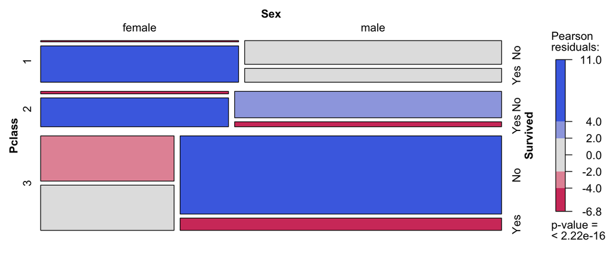

```r
tbl_mosaic <- full %>%

  filter(set=="train") %>%

  select(Survived, Pclass, Sex, AgeGroup=`Age Group`, title, Embarked, `FamilySize`) %>%

  mutate_all(as.factor)



mosaic(~Pclass+Sex+Survived, data=tbl_mosaic, shade=TRUE, legend=TRUE)
```

#### 0.1.12.3 Alluvial Diagram

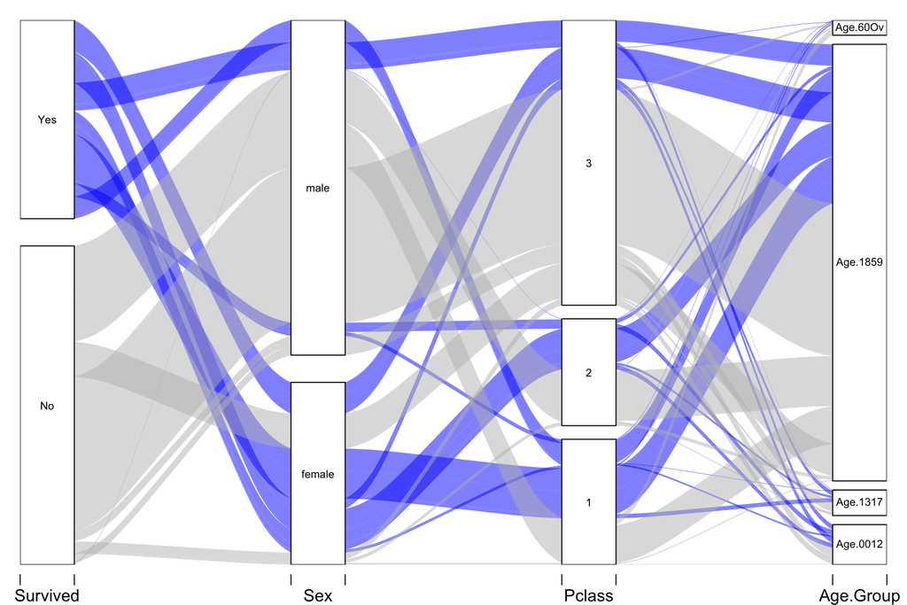

```r
library(alluvial)



tbl_summary <- full %>%

  filter(set=="train") %>%

  group_by(Survived, Sex, Pclass, `Age Group`, title) %>%

  summarise(N = n()) %>%

  ungroup %>%

  na.omit



alluvial(tbl_summary[, c(1:4)],

         freq=tbl_summary$N, border=NA,

         col=ifelse(tbl_summary$Survived == "Yes", "blue", "gray"),

         cex=0.65,

         ordering = list(

           order(tbl_summary$Survived, tbl_summary$Pclass==1),

           order(tbl_summary$Sex, tbl_summary$Pclass==1),

           NULL,

           NULL))
```

## 0.2 Machine learning algorithm v

**Supervised Learning** - Supervised learning is a data mining task of inferring a function from labeled training data.The training data consist of a set of training examples. In supervised learning, each example is a pair consisting of an input object (typically a vector) and the desired output value (also called the supervisory signal).

```
A supervised learning algorithm analyzes the training data and produces an inferred function, which can used for mapping new examples. An optimal scenario will allow for the algorithm to correctly determine the class labels for unseen instances. This requires the learning algorithm to generalize from the training data to unseen situations in a “reasonable” way.
```

**Unsupervised Learning** - In data mining or even in data science world, the problem of an unsupervised learning task is trying to find hidden structure in unlabeled data. Since the examples given to the learner are unlabeled, there is no error or reward signal to evaluate a potential solution.

**Training Set** - In machine learning, a training set is a dataset used to train a model. In training the model, specific features are picked out from the training set. These features are then incorporated into the model.

**Test Set** - The test set is a dataset used to measure how well the model performs at making predictions on that test set

###Prepare and keep data set.

```r
###lets prepare and keep data in the proper format



feauter1<-full[1:891, c("Pclass", "title","Sex","Embarked","FamilySized","ticket.size")]

response <- as.factor(train$Survived)

feauter1$Survived=as.factor(train$Survived)





###For Cross validation purpose will keep 20% of data aside from my orginal train set

##This is just to check how well my data works for unseen data

set.seed(500)

ind=createDataPartition(feauter1$Survived,times=1,p=0.8,list=FALSE)

train_val=feauter1[ind,]

test_val=feauter1[-ind,]
```

```r
####check the proprtion of Survival rate in orginal training data, current traing and testing data

round(prop.table(table(train$Survived)*100),digits = 1)
```

```
##
##   0   1
## 0.6 0.4
```

```r
round(prop.table(table(train_val$Survived)*100),digits = 1)
```

```
##
##   0   1
## 0.6 0.4
```

```r
round(prop.table(table(test_val$Survived)*100),digits = 1)
```

```
##
##   0   1
## 0.6 0.4
```

**Note - Go through each tab for different algorithms**